# CT0429 - Analisi Predittiva - aa 22/23 - Appello I

Nome Cognome - matricola

# Istruzioni

Salvate questo file con il nome `matricola.Rmd`. Questo sarà il file che dovrete consegnare. Il file deve compilare senza problemi: files che non possono essere compilati correttamente saranno penalizzati.

Per essere sicuri di poter trovare il file al momento della consegna potete controllare dove è il file quando compilate il file la prima volta usando il comando `getwd()`.

```r
getwd()
```

```
## [1] "/Users/alberto/Documents/_code/CT0429-analisi-predittiva/esami/appello1_22-23"
```

```r
## da cancellare quando siete sicuri di dove è il file
```

Attenzione - per tutto l’esame, se non specificato esplicitamente, il livello di significatività da usare è $\alpha = 0.02$

# Esercizio 1

Si desidera indagare quali caratteristiche di un’azienda possono risultare utili per predire il valore dell’azienda sul mercato. Per un campione di 75 aziende vengono raccolte le seguenti informazioni:

- `MarketValue`; il valore di mercato dell’azienda
- `Assets`: il valore del patrimonio dell’azienda (in migliaia di dollari)
- `Sales`: il totale delle vendite (in migliaia di dollari)
- `Profits`: i profitti (in migliaia di dollari)
- `CashFlow`: il flusso di cassa (in migliaia di dollari)
- `Employees`: il numero di dipendenti
- `Banks`: una variabile che indica se l’azienda è una banca

I dati sono contenuti del dataset `dex1` che si può caricare usando il seguente codice:

```r
dex1 <- read.csv("a01ex12_data.csv", header = TRUE)
```

### Es. 1.a

Si costruisca un primo modello lineare semplice `fit1` in cui la variabile risposta `MarketValue` viene spiegata in funzione del predittore `CashFlow`. Si commenti la significatività del modello e si derivi un intervallo di confidenza (a livello di confidenza 98%) per il coefficiente angolare relativo alla variabile `CashFlow` nel modello `fit11`. Si verifichi inoltre il sistema di ipotesi $H_0: \beta_{CashFlow} = 10$ VS $H_1: \beta_{CashFlow} \neq 10$

```r
fit1 <- lm(MarketValue ~ CashFlow, data = dex1)
summary(fit1)
```

```
##
## Call:
## lm(formula = MarketValue ~ CashFlow, data = dex1)
##
## Residuals:
##      Min       1Q   Median       3Q      Max
## -12537.0   -313.3    291.1    713.3   8124.7
##
## Coefficients:
##              Estimate Std. Error t value Pr(>|t|)
## (Intercept) -703.7460   294.2064  -2.392   0.0193 *
## CashFlow       9.2660     0.2276  40.716   <2e-16 ***
## ---
## Signif. codes:  0 '***' 0.001 '**' 0.01 '*' 0.05 '.' 0.1 ' ' 1
##
## Residual standard error: 2396 on 73 degrees of freedom
## Multiple R-squared:  0.9578, Adjusted R-squared:  0.9572
## F-statistic:  1658 on 1 and 73 DF,  p-value: < 2.2e-16
```

```r
confint(fit1, level = .98)
```

```
##                      1 %      99 %
## (Intercept) -1403.522375 -3.969549
## CashFlow        8.724745  9.807341
```

```r
library(car)
linearHypothesis(fit1, "CashFlow = 10")
```

```
## Linear hypothesis test
##
## Hypothesis:
## CashFlow = 10
##
## Model 1: restricted model
## Model 2: MarketValue ~ CashFlow
##
##   Res.Df       RSS Df Sum of Sq      F   Pr(>F)
## 1     74 478863633
## 2     73 419143264  1  59720369 10.401 0.001885 **
## ---
## Signif. codes:  0 '***' 0.001 '**' 0.01 '*' 0.05 '.' 0.1 ' ' 1
```

Rifiuto l’ipotesi nulla.

### Es. 1.b

Si produca una visualizzazione che mostri come la relazione tra la variabile `MarketValue` e `CashFlow`, mostrando la relazione stimata dal modello `fit1` e un intervallo di confidenza per il valore atteso di `MarketValue` in funzione della variabile `CashFlow`. Per quale valore di `CashFlow` è più stretto l’intervallo di confidenza?

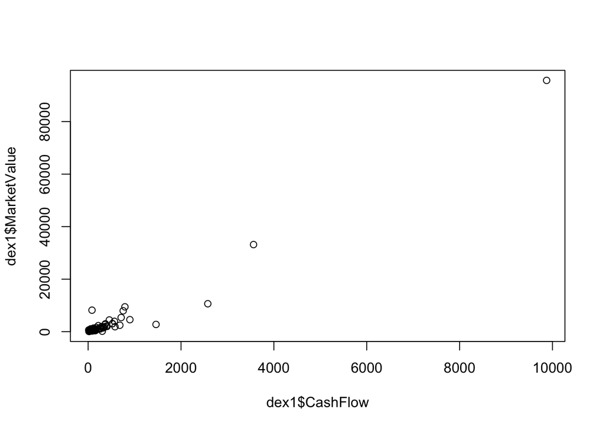

```r
plot(dex1$MarketValue ~ dex1$CashFlow)
```

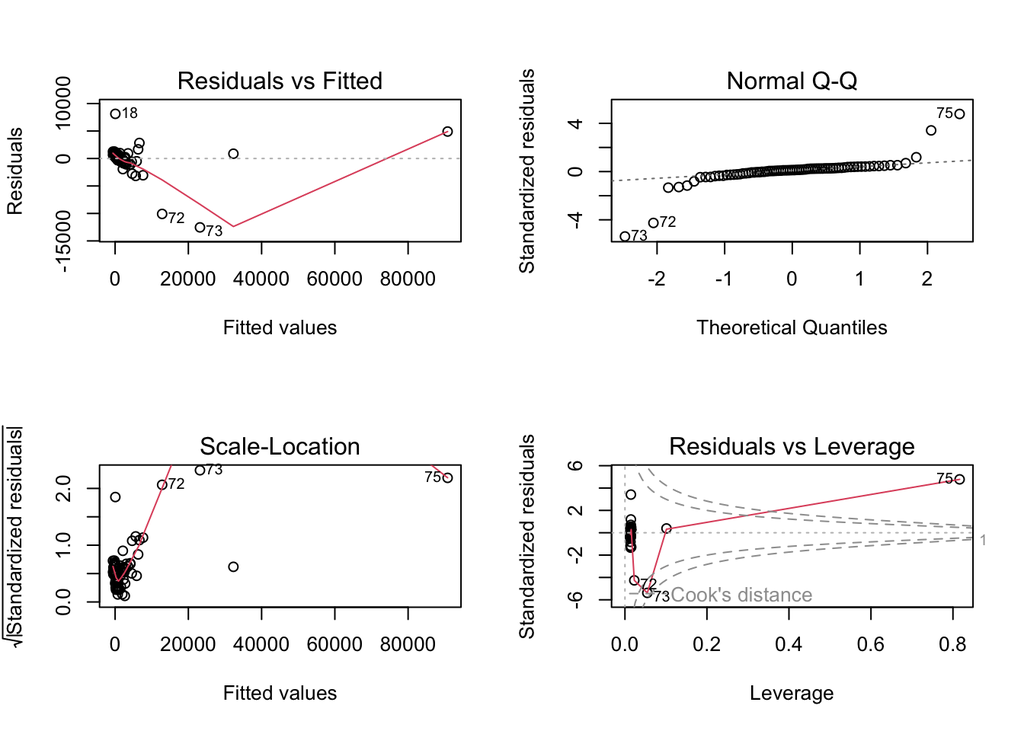

```r
par(mfrow = c(2,2))
plot(fit1)
```

### Es. 1.c

Si elenchino le assunzioni sottostanti il modello lineare semplice e si verifichi se queste sono soddisfatte per il modello `fit1`. Si suggerisca eventualmente come modificare il modello.

### Es. 1.d

Si stimi un modello lineare multiplo in cui tutte le variabili sono utilizzati come predittori. Si confronti il valore stimato di $\beta_{CashFlow}$ e la sua significatività nei due modelli: come si può interpretare il valore del parametro dei due modelli? Quale potrebbe essere la causa di una eventuale differenza del valore stimato per il parametro nei due modelli?

# Esercizio 2

Si usi ora lo stesso dataset `dex1` usato nell’esercizio 1 per individuare quali fattori possono permettere di predire se un’azienda è una banca, i.e. se la variabile `Banks` ha valore `Bank`:

```r
dex1 <- read.csv("a01ex12_data.csv", header = TRUE)
```

La variabile risposta ora è la variabile `Bank`, che può prendere valore `Bank` o `Not`: codifichiamo la variabile come un `factor` che abbia il valore `Not` come baseline:

```r
dex1$Banks <- factor(dex1$Banks, ordered = TRUE, levels = c("Not","Bank"))
table(dex1$Banks)
```

```
##
##  Not Bank
##   62   13
```

### Es. 2.a

Si stimi un modello `fit1` utile a verificare se la variabile `Assets` è un predittore significativo per predire se un’azienda è o meno una banca. Che effetto ha la variabile `Assets` sulla probabilità che un’azienda sia una banca?

### Es. 2.b

Si usi il modello stimato al punto precedente (2.a) per derivare un intervallo di confidenza al 98% per la probabilità che due aziende con un valore di `Assets` pari a 2000 e 20000 siano banche. Si produca inoltre una visualizzazione che mostri come varia la stima della probabilità che un’azienda sia una banca in funzione di `Assets` con un intervallo di confidenza al 98%.

### Es. 2.c

Si stimi ora un modello `fit2` utile a verificare se la variabile `Profits` è un predittore significativo per predire se un’azienda è o meno una banca: si commenti il risultato del modello. Come è possibile confrontare la bontà di adattamento dei due modelli `fit1` e `fit2`.

### Es. 2.d

Si prenda in considerazione il dataset `X` specificato nel codice seguente: questi dati sono un dataset diverso da quello `dex1` e non sono stati usati per stimare i modelli stimati fino ad ora. Usando il modello che si è trovato avere una migliore bontà di adattamento al punto precedente (2.c), si costruisca una matrice di confusione che permetta di valutare la capacità di predizione out-of-sample del modello calcolando il tasso di errore di classificazione (mis-classification rate).

```r
### è semplicemnte necessario far girare questo codice
testData <- data.frame(
  Assets = c(630, 6650, 7850, 1840, 1470, 144, 1430,
8580, 1460, 1090, 6180, 2650, 15100, 1030, 2220, 4520, 2120,
2240, 8280, 3020),
  Sales = c(212, 1690, 14700, 641, 1110, 899,
975, 3020, 2720, 267, 3030, 592, 2170, 931, 4540, 1010, 589,
491, 2320, 7780),
  MarketValue = c(141, 1040, 3480, 677, 878,
804, 185, 1910, 3210, 361, 1170, 680, 222, 728, 2060, 2030, 492,
510, 2560, 3400),
  Profits = c(2.3, 241, 381, 72.7, 109, 55.2,
21.7, 156, 247, 35.9, 168, 76, 48, 38.4, 128, 229, 17.8, 38.1,
175, 207),
  CashFlow = c(46.5, 237, 802, 71.3, 227, 149, 37.1,
358, 361, 33.6, 315, 73.5, 91.3, 106, 367, 165, 46.3, 93.1, 304,
438),
  Employees = c(0.877, 2.75, 109, 9.4, 9.84, 4.1, 2.89, 30.7,
32.4, 1.77, 9.71, 3.89, 6.04, 5.2, 48.6, 7.13, 5.09, 4.54, 21.1,
30),
  Banks = c("Bank", "Not", "Not", "Not", "Not", "Bank",
"Not", "Not", "Not", "Not", "Not", "Not", "Bank", "Bank", "Not",
"Bank", "Not", "Bank", "Bank", "Not"))

testData[1:2,]
```

```
##   Assets Sales MarketValue Profits CashFlow Employees Banks
## 1    630   212         141     2.3     46.5     0.877  Bank
## 2   6650  1690        1040   241.0    237.0     2.750   Not
```